# Combining Plots with ggplot2

# ggplot2 is very flexible

`ggplot2` is flexible, but fussy. It really wants to be told what to do, and it takes instructions through factors and groups.

As an example, let’s make this chart.

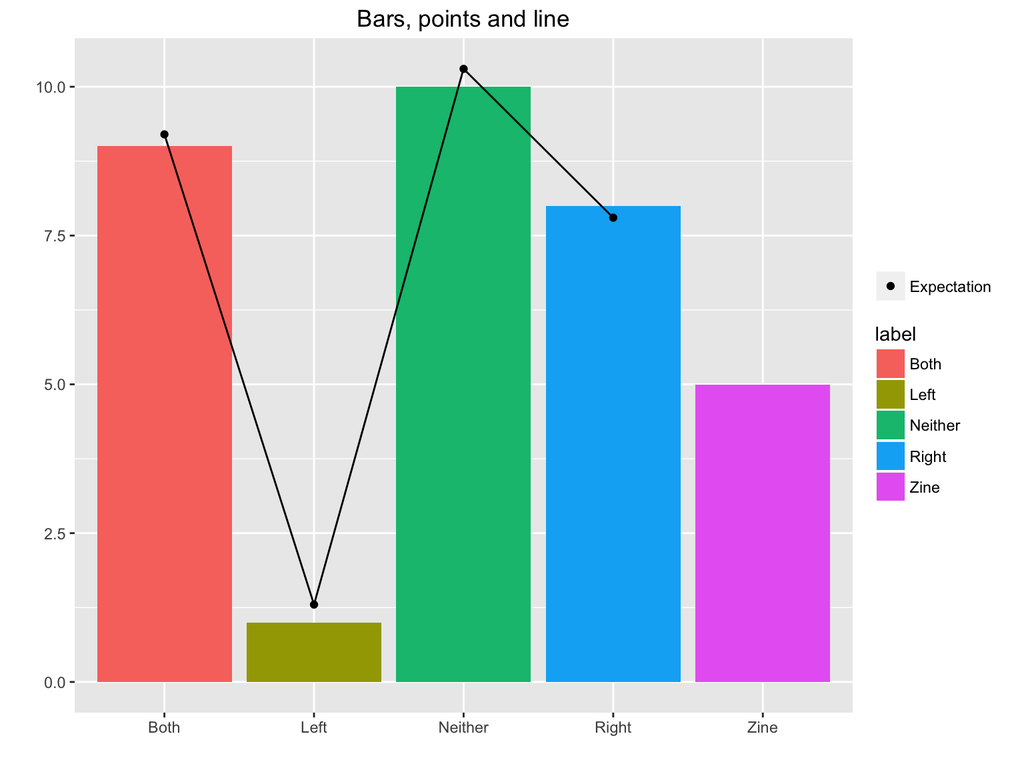

# Bar Chart

We’re going to use this data set:

```r
data_multi_chart <- data.frame(
  label = c("Left", "Right", "Both", "Neither", "Zine"),
  bar = c(1,8,9,10,5),
  points = c(1.3, 7.8, 9.2, 10.3, NA)
)
```

Colour can be added through the aesthetic `fill`, we will add the colour to the specific `geom_` we wish to target so that other geoms are not coloured as well

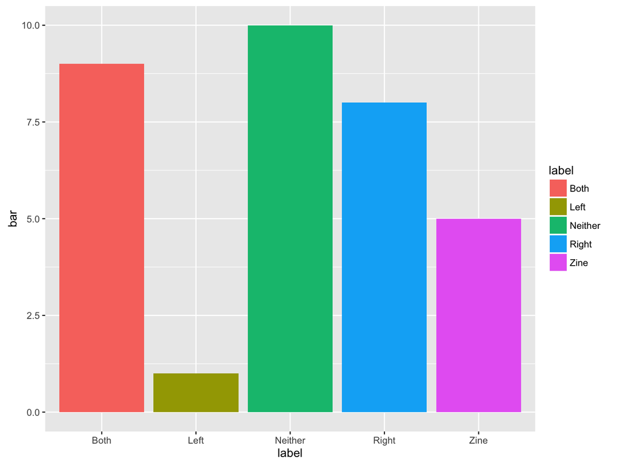

```r
ggplot(data = data_multi_chart, aes(x = label, y = bar)) +
  geom_bar(aes(fill = label), stat = "identity")
```

# Adding Points

Individual geoms can be given their own aesthetic mappings:

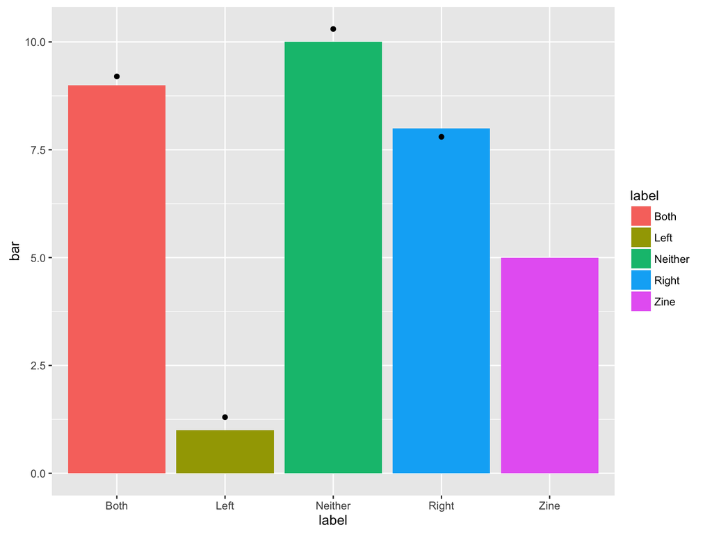

```r
ggplot(data = data_multi_chart, aes(x = label, y = bar)) +
  geom_bar(aes(fill = label), stat = "identity") +
  geom_point(aes(y = points))
```

# Adding Lines

Up till now everything has been easy, but the easiest way to add lines between the `geom_points` requires us to use `stat_summary`

```
## No summary function supplied, defaulting to `mean_se()
```

```
## geom_path: Each group consists of only one observation. Do you need to
## adjust the group aesthetic?
```

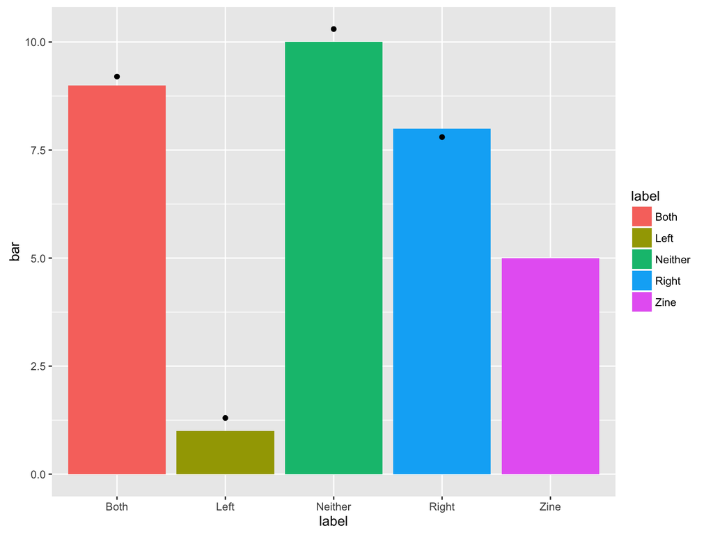

```r
ggplot(data = data_multi_chart, aes(x = label, y = bar)) +
  geom_bar(aes(fill = label), stat = "identity") +
  geom_point(aes(y = points)) +
  stat_summary(geom="line", aes(y = points))
```

The aesthetic `group` allows modelling geoms to decide how to collate points, typically by a column of the data.frame.

In our case, we want all `geom_point`s to be considered in the same group:

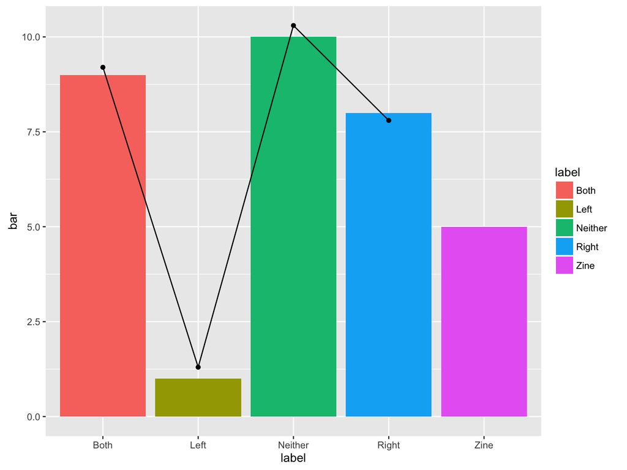

```r
ggplot(data = data_multi_chart, aes(x = label, y = bar)) +
  geom_bar(aes(fill = label), stat = "identity") +
  geom_point(aes(y = points)) +
  stat_summary(geom="line", aes(y = points, group = 1))
```

# Adding the legend

Legends (or guides) in ggplot2 can be slightly more frustrating than ideal.

To get a legend entry we need two things:

- The `geom_point` geom must have a color or fill
- An appropriate `scale_*_manual` must be added for the color or fill

The following works quite nicely:

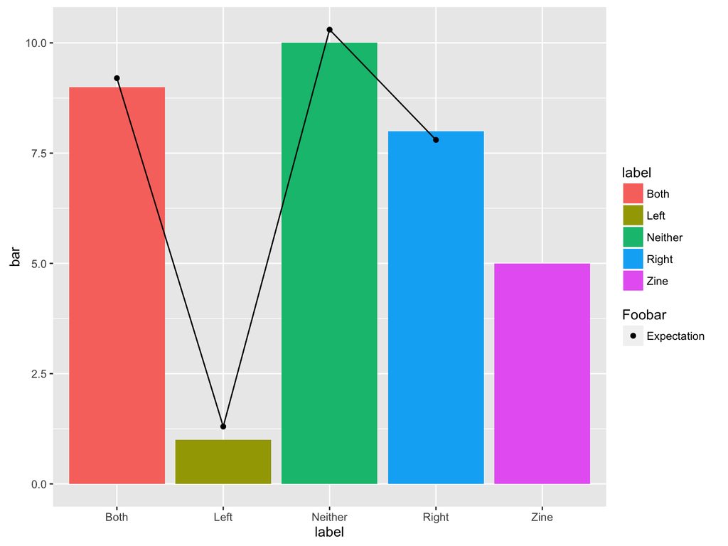

```r
ggplot(data = data_multi_chart, aes(x = label, y = bar)) +
  geom_bar(aes(fill = label), stat = "identity") +
  geom_point(aes(y = points, color = "Expectation")) +
  stat_summary(geom="line", aes(y = points, group = 1)) +
  scale_color_manual(name = "Foobar", values="1")
```

# How about making that with ggplotly?

This comes under the “that’s a little custom, it doesn’t work - try native plotly”

```r
library(plotly)
ggplotly(
ggplot(data = data_multi_chart, aes(x = label, group = 1)) +
  geom_bar(aes(y = bar, fill = label), stat = "identity") +
  geom_point(aes(y = points, color = "Expectation")) +
  stat_summary(geom="line", aes(y = points)) +
  xlab("") + ylab("") + ggtitle("Bars, points and line") +
  scale_color_manual(name = "", values="4"))
```

[interactive chart not shown]